# Projekt zaliczeniowy NLP - Karol Klimek, Paweł Lonca i Julita Sobiczewska

Kod ten jest pracą stworzoną przez z nas w ramach projektu na zaliczenie z przedmiotu Przetwarzanie Języka Naturalnego

```python
import pandas as pd
import numpy as np
import re
```

# Wstępna analiza danych EmoContext

Posiadamy następujące pliki w folderze `data`:

```python
from google.colab import files
uploaded = files.upload()
```

Upload widget is only available when the cell has been executed in the current browser session. Please rerun this cell to enable.

```
Saving test_with_labels.txt to test_with_labels.txt
Saving test_without_labels.txt to test_without_labels.txt
Saving training.txt to training.txt
Saving validation.txt to validation.txt
```

## Zestaw treningowy

```python
training_df = pd.read_csv("training.txt", sep='\t')
```

```python
training_df.head()
```

|  | id | turn1 | turn2 | turn3 | label |
| --- | --- | --- | --- | --- | --- |
| 0 | 0 | Don't worry I'm girl | hmm how do I know if you are | What's ur name? | others |
| 1 | 1 | When did I? | saw many times i think -_- | No. I never saw you | angry |
| 2 | 2 | By | by Google Chrome | Where you live | others |
| 3 | 3 | U r ridiculous | I might be ridiculous but I am telling the truth. | U little disgusting whore | angry |
| 4 | 4 | Just for time pass | wt do u do 4 a living then | Maybe | others |

```python
training_df.tail()
```

|  | id | turn1 | turn2 | turn3 | label |
| --- | --- | --- | --- | --- | --- |
| 30155 | 30155 | I don't work | I could take your shift | I am a student | others |
| 30156 | 30156 | I'm not getting you 😭😭😭 | Why are you crying?? | Because you are not making any sense | sad |
| 30157 | 30157 | Haha | no, seriously. What is up with that o-o | Had your breakfast? | others |
| 30158 | 30158 | Do you sing? | yea a lil | Nice | others |
| 30159 | 30159 | Me to | People be driving me crazy | Come on sleep with me | others |

## Zestaw walidacyjny

```python
validation_df = pd.read_csv("validation.txt", sep = "\t")
```

```python
validation_df.head()
```

|  | id | turn1 | turn2 | turn3 | label |
| --- | --- | --- | --- | --- | --- |
| 0 | 0 | Then dont ask me | YOURE A GUY NOT AS IF YOU WOULD UNDERSTAND | IM NOT A GUY FUCK OFF | angry |
| 1 | 1 | Mixed things such as?? | the things you do. | Have you seen minions?? | others |
| 2 | 2 | Today I'm very happy | and I'm happy for you ❤ | I will be marry | happy |
| 3 | 3 | Woah bring me some | left it there oops | Brb | others |
| 4 | 4 | it is thooooo | I said soon master. | he is pressuring me | others |

```python
validation_df.tail()
```

|  | id | turn1 | turn2 | turn3 | label |
| --- | --- | --- | --- | --- | --- |
| 2750 | 2750 | U are my book | book for what? ugliness? THANK YOU | U like ur self | others |
| 2751 | 2751 | I'll be crying | You just want to make ppl cry:P | ppl | others |
| 2752 | 2752 | Thanks for sending | hahaha you're welcome! 😤😤 | Why are u not sending | others |
| 2753 | 2753 | Write it | Mr. F | U understand me? | others |
| 2754 | 2754 | Yes | okay I'll give you a ticket | Ohk | others |

## Zestaw testowy

```python
test_df = pd.read_csv("test_without_labels.txt", sep='\t')
```

```python
test_df.head()
```

|  | id | turn1 | turn2 | turn3 |
| --- | --- | --- | --- | --- |
| 0 | 0 | Hmm | What does your bio mean? | I don’t have any bio |
| 1 | 1 | What you like | very little things | Ok |
| 2 | 2 | Yes | How so? | I want to fuck babu |
| 3 | 3 | what did you guess | what what | fuck |
| 4 | 4 | We ? | of course we will! | What gender movies you like?? |

```python
test_df.tail()
```

|  | id | turn1 | turn2 | turn3 |
| --- | --- | --- | --- | --- |
| 5504 | 5504 | Not youuu | I also didn't not not. | How to calll |
| 5505 | 5505 | Welcome | Why, thank you. | I don't know, you tell |
| 5506 | 5506 | Yes | IF ONLY I COULD AFFORD THIS | How are you |
| 5507 | 5507 | For my information | It's our responsibility to clarify everything. | What is mountain dew? |
| 5508 | 5508 | ok........... where you work ? | I'm off this whole week | ok.............. |

```python
test_set_answers = pd.read_csv("test_with_labels.txt", sep="\t", usecols=["label"])
```

```python
test_set_answers.head()
```

|  | label |
| --- | --- |
| 0 | others |
| 1 | others |
| 2 | others |
| 3 | others |
| 4 | others |

```python
test_set_answers.tail()
```

|  | label |
| --- | --- |
| 5504 | others |
| 5505 | others |
| 5506 | others |
| 5507 | others |
| 5508 | others |

## Niepotrzebne kolumny

Jako, że kolumna `id` duplikuje informację z pandasowego indeksu, usuwam ją:

```python
training_df.drop('id', axis=1, inplace=True)
test_df.drop('id', axis=1, inplace=True)
validation_df.drop('id', axis=1, inplace=True)
```

## Brakujące dane

Nie ma żadnych braków danych:

```python
training_df.isnull().any().any()
```

```
False
```

```python
test_df.isnull().any().any()
```

```
False
```

```python
validation_df.isnull().any().any()
```

```
False
```

## Kodowanie emotikonek

W niektórych wiadomościach występują emotikonki. Myślę, że mogą stanowić istotną cechę przy wyborze kategorii. Jak są kodowane?

```python
emoticon_row = training_df.iloc[21]
```

```python
emoticon_row.loc['turn2']
```

```
'Yes I love to dance 😻'
```

```python
emoticon_row.loc['turn3']
```

```
'😂😂😂 so you have legs too'
```

Okazuje się, że emojis są częścią Unicode i są kodowane tak samo jako inne znaki. Do ich poprawnego wyświetlenia potrzebna jest czcionka, która potrafi renderować specjalne (jak na standardy alfabetu łacińskiego znaki), np. chińskie znaki czy emotikony (ang. glyphs). Więcej tutaj: https://stackoverflow.com/questions/19091320/special-characters-emoticons-in-text-file

```python
emoticon_row.loc['turn3'].encode("utf-8")
```

```
b'\xf0\x9f\x98\x82\xf0\x9f\x98\x82\xf0\x9f\x98\x82 so you have legs too'
```

```python
emoticon_row.loc['turn2'].encode("utf-8")
```

```
b'Yes I love to dance \xf0\x9f\x98\xbb'
```

```python
emoticon_row_2 = training_df.iloc[38]
emoticon_row_2
```

```
turn1                   That was mean
turn2    haha the truth usually is. 👍
turn3            Are you bored of me?
label                          others
Name: 38, dtype: object
```

```python
emoticon_row_2.loc['turn2'].encode("utf-8")
```

```
b'haha the truth usually is. \xf0\x9f\x91\x8d'
```

Jak widać poniżej `b''` koduje w postaci ASCII:

```python
emoticon_row_2.loc['turn2'].encode("utf-8")[0]
```

```
104
```

Emotikonka ma długość 1 (w kodowaniu Unicode):

```python
len(emoticon_row_2.loc['turn2'][-1])
```

```
1
```

## Rozkład zmiennych

```python
def get_set_statistics(set_df):
    """
    The function returns a dataframe that produces aggregated summary for each of four columns in the input dataframe (`set_df`): `label`, `turn1`, `turn2`, `turn3`.
    Aggregated summary contains information on frequency (`count`) and relative frequency (`freq`) for the `label` column.
    Each of `turn*` columns is summarised with
        the average length of the message (`average_len`),
        standard deviation of the message's length (`std_avg_len`)
        the length of the shortest message in the column (`min_len`),
        the length of the longest message in the the column (`max_len`).
    """

    no_rows = set_df.shape[0]

    aggregation = {
    'label': {
        'count': 'count',
        'freq': lambda x: x.shape[0]/no_rows
    },
    'turn1': {
        'average_len': lambda x: np.mean(x.str.len()),
        'std_avg_len': lambda x: np.std(x.str.len()),
        'min_len': lambda x: np.min(x.str.len()),
        'max_len': lambda x: np.max(x.str.len())
    },
    'turn2': {
        'average_len': lambda x: np.mean(x.str.len()),
        'std_avg_len': lambda x: np.std(x.str.len()),
        'min_len': lambda x: np.min(x.str.len()),
        'max_len': lambda x: np.max(x.str.len())
    },
    'turn3': {
        'average_len': lambda x: np.mean(x.str.len()),
        'std_avg_len': lambda x: np.std(x.str.len()),
        'min_len': lambda x: np.min(x.str.len()),
        'max_len': lambda x: np.max(x.str.len())
    }
    }

    print("The set contains {} observations".format(set_df.shape[0]))
    aggregated_df = set_df.groupby(by='label').agg(aggregation).round(2).sort_values(by=[('label', 'count')], ascending=False)
    return aggregated_df
```

### Treningowe

```python
get_set_statistics(training_df)
```

```
The set contains 30160 observations
```

| label | label count | label freq | turn1 average_len | turn1 std_avg_len | turn1 min_len | turn1 max_len | turn2 average_len | turn2 std_avg_len | turn2 min_len | turn2 max_len | turn3 average_len | turn3 std_avg_len | turn3 min_len | turn3 max_len |
| --- | --- | --- | --- | --- | --- | --- | --- | --- | --- | --- | --- | --- | --- | --- |
| others | 14948 | 0.50 | 17.46 | 13.61 | 1 | 308 | 25.49 | 16.34 | 1 | 149 | 16.93 | 15.01 | 1 | 630 |
| angry | 5506 | 0.18 | 20.92 | 16.44 | 1 | 175 | 26.50 | 16.62 | 1 | 114 | 22.19 | 17.21 | 1 | 197 |
| sad | 5463 | 0.18 | 18.55 | 14.54 | 1 | 238 | 24.35 | 15.43 | 1 | 115 | 18.86 | 14.82 | 1 | 142 |
| happy | 4243 | 0.14 | 19.96 | 13.43 | 1 | 130 | 27.93 | 16.11 | 1 | 111 | 14.09 | 12.20 | 1 | 160 |

### Walidacyjne

```python
get_set_statistics(validation_df)
```

```
The set contains 2755 observations
```

| label | label count | label freq | turn1 average_len | turn1 std_avg_len | turn1 min_len | turn1 max_len | turn2 average_len | turn2 std_avg_len | turn2 min_len | turn2 max_len | turn3 average_len | turn3 std_avg_len | turn3 min_len | turn3 max_len |
| --- | --- | --- | --- | --- | --- | --- | --- | --- | --- | --- | --- | --- | --- | --- |
| others | 2338 | 0.85 | 17.54 | 13.11 | 1 | 122 | 25.69 | 16.72 | 2 | 101 | 16.92 | 13.54 | 1 | 206 |
| angry | 150 | 0.05 | 19.01 | 13.25 | 1 | 88 | 27.91 | 17.09 | 3 | 81 | 19.10 | 15.60 | 3 | 111 |
| happy | 142 | 0.05 | 18.85 | 12.76 | 1 | 66 | 28.30 | 17.19 | 3 | 95 | 13.97 | 16.55 | 1 | 119 |
| sad | 125 | 0.05 | 19.94 | 27.21 | 2 | 286 | 22.90 | 14.42 | 3 | 82 | 19.78 | 13.51 | 1 | 66 |

### Testowe

Jako, że ramka danych z obserwacjami testowymi nie zawiera kategorii, tworzę tymczasową ramkę danych:

```python
test_df['label'] = test_set_answers
test_df.head()
```

|  | turn1 | turn2 | turn3 | label |
| --- | --- | --- | --- | --- |
| 0 | Hmm | What does your bio mean? | I don’t have any bio | others |
| 1 | What you like | very little things | Ok | others |
| 2 | Yes | How so? | I want to fuck babu | others |
| 3 | what did you guess | what what | fuck | others |
| 4 | We ? | of course we will! | What gender movies you like?? | others |

```python
get_set_statistics(test_df)
```

```
The set contains 5509 observations
```

| label | label count | label freq | turn1 average_len | turn1 std_avg_len | turn1 min_len | turn1 max_len | turn2 average_len | turn2 std_avg_len | turn2 min_len | turn2 max_len | turn3 average_len | turn3 std_avg_len | turn3 min_len | turn3 max_len |
| --- | --- | --- | --- | --- | --- | --- | --- | --- | --- | --- | --- | --- | --- | --- |
| others | 4677 | 0.85 | 17.69 | 14.33 | 1 | 293 | 25.91 | 16.74 | 1 | 105 | 16.85 | 16.22 | 1 | 460 |
| angry | 298 | 0.05 | 17.91 | 12.73 | 1 | 116 | 24.60 | 15.41 | 4 | 85 | 19.77 | 14.38 | 1 | 101 |
| happy | 284 | 0.05 | 20.54 | 15.98 | 1 | 172 | 25.91 | 14.49 | 4 | 77 | 13.37 | 14.00 | 1 | 85 |
| sad | 250 | 0.05 | 19.95 | 31.03 | 1 | 458 | 25.50 | 16.75 | 3 | 82 | 17.90 | 23.07 | 1 | 308 |

```python
test_df.drop('label', axis=1, inplace=True)
```

## Najkrótsze wiadomości

Najkrótsze wiadomości w zestawie mają tylko jeden znak. Czy są to tylko emotikonki? Co z wiadomościami trochę dłuższymi (np. do czterech znaków włącznie)?

```python
def get_shortest_messages(set_df, one_char = False, limit = 4, head=True):
    if one_char:
        # the maximum length of the message is one
        limit = 1
    mask = (set_df['turn1'].str.len() <= limit) | (set_df['turn2'].str.len() <= limit) | (set_df['turn3'].str.len() <= limit)
    if head:
        return set_df.loc[mask].head(15)
    return set_df.loc[mask]
```

### Treningowe

```python
get_shortest_messages(training_df, one_char=True)
```

|  | turn1 | turn2 | turn3 | label |
| --- | --- | --- | --- | --- |
| 19 | Ur creator is very bad | you are only the creator of your brain. | 😑 | sad |
| 24 | Bcoz u dont know wat is to miss someone | but sometimes one can't express the same | 😢 | sad |
| 67 | 😂 😂 right | Appatasiri. High five then! 🖑😂😂😂😂 | 😂 | happy |
| 152 | I have a good sense of humor | I think that's funny. | 😁 | happy |
| 153 | But who paid | still waiting | 😂 | happy |
| 182 | Haha! I act so dumb sometimes and I knew it | Haha. How was it though? :3 | 😁 | others |
| 191 | Tell me about it | your header | 😂 | happy |
| 206 | ? | u asked me if u cn ask me something | I mean pussy cat | others |
| 218 | You cannot see my hair | I'm in your closet | 😂 | happy |
| 265 | K think me as husband | Spoken like a person who has never been married. | S | others |
| 311 | Only 2 are left | Count me in! | 😂 | happy |
| 402 | I'm so excited | AHHH I'LL HAVE TO LOOK OUT FOR YOU THEN | 👌 | happy |
| 430 | But u seem so unreal | i am! | 😞 | sad |
| 444 | K | U are ok | I am not ok | sad |
| 498 | I am a good boy | are you cute 😺 | S | others |

```python
get_shortest_messages(training_df)
```

|  | turn1 | turn2 | turn3 | label |
| --- | --- | --- | --- | --- |
| 2 | By | by Google Chrome | Where you live | others |
| 7 | Ok | ok im back!! | So, how are u | others |
| 9 | Bay | in the bay | 😘 love you | others |
| 10 | I hate my boyfriend | you got a boyfriend? | Yes | angry |
| 13 | Bad | Bad bad! That's the bad kind of bad. | I have no gf | sad |
| 14 | Ok get it...... | I made it an option | Ok | others |
| 15 | Money money and lots of money😍😍 | I need to get it tailored but I'm in love with... | 😁😁 | happy |
| 16 | My gf left ne | Get over it. Go out with someone else. | Me* | sad |
| 18 | You are lying and i know that | I KNOW YOU'RE LYING, AB BYS | 😭😭 | sad |
| 19 | Ur creator is very bad | you are only the creator of your brain. | 😑 | sad |
| 24 | Bcoz u dont know wat is to miss someone | but sometimes one can't express the same | 😢 | sad |
| 25 | Yeah | i'll ask around | Which is your favourite movie | others |
| 29 | wth | my thoughts exactly! | you know you are a machine, right? | others |
| 30 | so rude | why? | u didnt ans my question | angry |
| 31 | ok i will | THANK YOU | wlcm | others |

### Walidacyjne

```python
get_shortest_messages(validation_df, one_char=True)
```

|  | turn1 | turn2 | turn3 | label |
| --- | --- | --- | --- | --- |
| 8 | Shall we meet | you say- you're leaving soon...anywhere you wa... | ? | others |
| 22 | Send me any video or songs | Video or Text | S | others |
| 131 | I mean, what else? | Aiyyo! at all XD | 😂 | happy |
| 168 | Did you married me | yes I did | ? | others |
| 263 | ? | ITS TOO PINK FOR ME. | Too pink | others |
| 305 | ? | you know well what you did ! | You you don't like it | others |
| 348 | better do skydiving | If at first you don't succeed, don't take up s... | k | others |
| 354 | ? | Go on... This thing? | R u there | others |
| 394 | U and me | I don't WANT to handle you... | 😢 | sad |
| 409 | Wr r frm 😜 | lol. I saw 1st half last night. 😜 | 😅 | happy |
| 411 | I also like to sing | You can't! Never!Though you can sing like your... | 😐 | others |
| 438 | 3 | What? You don't have time only | Time for what | others |
| 452 | Where in gujrat | Trier - a small German city near the Luxembour... | 😮 | others |
| 482 | How many bf did you have? | One girlfriend, three boyfriends. | 😂 | happy |
| 502 | I think so.. | you think what? | 😂 | others |

```python
get_shortest_messages(validation_df)
```

|  | turn1 | turn2 | turn3 | label |
| --- | --- | --- | --- | --- |
| 3 | Woah bring me some | left it there oops | Brb | others |
| 8 | Shall we meet | you say- you're leaving soon...anywhere you wa... | ? | others |
| 10 | Your pic pz | thank you X‑D | wc | others |
| 15 | Ok | Thank you. xD | What about cortanan | others |
| 21 | But... | then | I'm feeling nervous | sad |
| 22 | Send me any video or songs | Video or Text | S | others |
| 23 | Why | why what | How r u | others |
| 33 | You | how about ur family.. Still single? | Can you love mi | others |
| 35 | Hell | im already there xoxo 😂 | Good night sweet dreams baby | others |
| 39 | Ok | ... tries to ignore pain :'( | Where to go? | others |
| 42 | So tht u r body can get heat | I heat more than that up ;] | Ok | others |
| 44 | Why! | Because they are BFF's ? | Who are BFF's | others |
| 45 | Make | how | I don't know I think u know | others |
| 52 | Okay | Hello! How are you? | Good n u | others |
| 53 | No .l human | Are you sure? | Yeah | others |

### Testowe

```python
get_shortest_messages(test_df, one_char=True)
```

|  | turn1 | turn2 | turn3 |
| --- | --- | --- | --- |
| 9 | Nice to meet u | Hi, nice to meet you too! 😸😂 | 😁 |
| 63 | Whenever I want | same pinch!!! =/ | 😁 |
| 76 | Let me love you | Amazing song though ! :'‑) | 😂 |
| 92 | Yes. Yes. Yes. Yes. Yes. Yes. Yes. Yes | no yes no yes | 😂 |
| 118 | I'm also good | you're welcome | 😀 |
| 124 | Wat do u mean? | i mean ear :D LOL | 😂 |
| 195 | ? | sounds like some young kids tag names frm the ... | sounds like you wanna have sex |
| 382 | Coz I want to | WHY ARE WE YELLING? | 🙄 |
| 428 | Love 😘👭👫❤️❤️you | looking so beautiful ma ! 😀 | 💛 |
| 434 | 💩 | Already did. | 😆 |
| 436 | Lets play the emojii game | yup I guess | 🏀 |
| 439 | I want to ask my crush out | Your crush may crush you. So be careful what y... | 🎈 |
| 443 | I like jalebi | 😒 Weird. | 🙄 |
| 571 | I was just kidding | Not you. | 😆 |
| 595 | Tell me magical words | Tell me those 3 magical words. I have cousin.💓💓 | 💔 |

```python
get_shortest_messages(test_df)
```

|  | turn1 | turn2 | turn3 |
| --- | --- | --- | --- |
| 0 | Hmm | What does your bio mean? | I don’t have any bio |
| 1 | What you like | very little things | Ok |
| 2 | Yes | How so? | I want to fuck babu |
| 3 | what did you guess | what what | fuck |
| 4 | We ? | of course we will! | What gender movies you like?? |
| 9 | Nice to meet u | Hi, nice to meet you too! 😸😂 | 😁 |
| 10 | Yupp | why? | Don't know I'm tired |
| 13 | First you hurt me | okay | So I talked rude |
| 17 | by | In Suits. | have good day |
| 24 | sure will u cal me ni8 | Ok | then |
| 29 | Uuu | no i'n not !! what's wrong with you ?!?! | I hate uuu |
| 31 | Ok | Hey you don't belong here! | I belong here |
| 37 | Buy | Oh, you're buying me a car? Okays | See u soon |
| 44 | I already heard of ir | that proves a lot. | It |
| 46 | Love u anyways | Forever and a day | Bye |

Powyższe ramki danych pokazują, że wiadomości o długości niekoniecznie są emotikonkami. Mogą to być pojedyncze litery lub znaki interpunkcyjne.

## Emotikonki i kategorie

Czy istnieje zależność pomiędzy ikonką występującą, w którejś wiadomości a kategorią (`label`)?

Filtruję tylko te konwersacje, gdzie występuje co najmniej jedna emotikonka. Każda emotikonka jest zapisana w następujący sposób: `\x..\x..\x..\x..`, gdzie `.` to cyfra lub litera.

```python
emoji_pattern = re.compile(u"(["
u"\U0001F600-\U0001F64F"  # emoticons
u"\U0001F300-\U0001F5FF"  # symbols & pictographs
u"\U0001F680-\U0001F6FF"  # transport & map symbols
u"\U0001F1E0-\U0001F1FF"  # flags (iOS)
                "])", flags= re.UNICODE)
```

```python
def is_row_with_emojis(cell):
    if len(re.findall(emoji_pattern, cell)) > 0:
        return True
    return False
```

```python
def purge_non_emojis(cell):
    return ''.join(re.findall(emoji_pattern, cell))
```

```python
def get_rows_with_emoticons(set_df):
    """
    """
    mask = (set_df['turn1'].apply(is_row_with_emojis)) | (set_df['turn2'].apply(is_row_with_emojis)) | (set_df['turn3'].apply(is_row_with_emojis))

    # filtered out rows don't contain any emojis
    emojis_df = set_df.loc[mask]

    # keep the `label` column
    label_col = emojis_df['label']

    emojis_df = emojis_df.applymap(purge_non_emojis)

    emojis_df['label'] = label_col

    return emojis_df
```

### Treningowe

```python
training_df_emojis_only = get_rows_with_emoticons(training_df)

training_df_emojis_only.head()
```

|  | turn1 | turn2 | turn3 | label |
| --- | --- | --- | --- | --- |
| 9 |  |  | 😘 | others |
| 15 | 😍😍 | 😍 | 😁😁 | happy |
| 18 |  |  | 😭😭 | sad |
| 19 |  |  | 😑 | sad |
| 21 |  | 😻 | 😂😂😂 | happy |

### Walidacyjne

```python
validation_df_emojis_only = get_rows_with_emoticons(validation_df)

validation_df_emojis_only.head()
```

|  | turn1 | turn2 | turn3 | label |
| --- | --- | --- | --- | --- |
| 13 |  | 😿 |  | sad |
| 16 |  | 😹 |  | others |
| 35 |  | 😂 |  | others |
| 47 | 😂 |  |  | others |
| 56 |  |  | 😂😂 | happy |

### Testowe

```python
# tymczasowo dodaj `label` do `test_df`
test_df['label'] = test_set_answers
```

```python
test_df_emojis_only = get_rows_with_emoticons(test_df)

test_df_emojis_only.head()
```

|  | turn1 | turn2 | turn3 | label |
| --- | --- | --- | --- | --- |
| 6 |  |  | 😁 | happy |
| 9 |  | 😸😂 | 😁 | happy |
| 14 | 🙊 | 😏 | 🙊 | others |
| 19 |  | 👍 |  | others |
| 21 |  | 😁😁😁😁 |  | others |

```python
test_df.drop('label', axis=1, inplace=True)
```

```python
def get_percentage_emojis_rows(df_full, df_emojis_only):
    return df_emojis_only.shape[0]/df_full.shape[0]
```

```python
### Treningowe
get_percentage_emojis_rows(training_df, training_df_emojis_only)
```

```
0.16982758620689656
```

```python
### Walidacyjne
get_percentage_emojis_rows(validation_df, validation_df_emojis_only)
```

```
0.10417422867513612
```

```python
### Testowe
get_percentage_emojis_rows(test_df, test_df_emojis_only)
```

```
0.11944091486658195
```

## Unikalne emotikonki w zbiorze

Znalezienie unikalnych emotikonek w zbiorze ma za zadanie pomóc w ręcznym sklasyfikowaniu poszczególnych emotikonek w czterech kategoriach. Kategoria `others` ma zostać użyta tylko jeżeli nie jesteśmy pewni do której z trzech pozostałych kategorii wrzucić emotikonkę. Działam jedynie na danych treningowych.

```python
training_df_emojis_only = get_rows_with_emoticons(training_df)
```

```python
testowa_df = get_rows_with_emoticons(training_df).head(5)
```

```python
def get_unique_emojis(set_df):
    """
    Given a dataframe get a set of unique emojis
    from the input dataframe.
    """

    unique_emojis = set()

    for _, *cells in set_df.drop(['label'], axis=1).itertuples():
        for cell in cells:
            emojis = list(cell)
            unique_emojis.update(emojis)
    return unique_emojis
```

```python
unique_emojis_training_set = get_unique_emojis(training_df_emojis_only)
```

```python
len(unique_emojis_training_set)
```

```
221
```

```python
unique_emojis_training_set
```

```
{'🌍',
 '🌞',
 '🌟',
 '🌱',
 '🌷',
 '🌸',
 '🌹',
 '🍌',
 '🍒',
 '🍓',
 '🍗',
 '🍜',
 '🍞',
 '🍭',
 '🍰',
 '🍶',
 '🍷',
 '🍺',
 '🍻',
 '🍼',
 '🍾',
 '🎁',
 '🎂',
 '🎃',
 '🎈',
 '🎉',
 '🎧',
 '🎵',
 '🎶',
 '🏀',
 '🏃',
 '🏋',
 '🏕',
 '🏖',
 '🏡',
 '🏣',
 '🏻',
 '🏼',
 '🏽',
 '🏾',
```

[output cut: 166 more lines]

```
 '🙇',
 '🙈',
 '🙉',
 '🙊',
 '🙋',
 '🙌',
 '🙍',
 '🙏',
 '🚌',
 '🚗',
 '🚘',
 '🚦',
 '🚩',
 '🚬',
 '🛰'}
```

# Naiwny Klasyfikator Bayesa

Zakłada, że słowa nie są ze sobą powiązane. Liczy prawdopodobieństwo, że dany dokument należy do pewnej klasy:

[figure not shown]

gdzie:

D - dokument (w naszym przypadku trzecia wypowiedź w dialogu)

w - słowo

C - klasa

```python
from sklearn.feature_extraction.text import TfidfVectorizer, TfidfTransformer, CountVectorizer
from sklearn.naive_bayes import MultinomialNB
from sklearn.pipeline import Pipeline
from sklearn.metrics import classification_report
```

```python
naive_bayes = Pipeline([
    ('vect', CountVectorizer()),
    ('tfidf', TfidfTransformer()),
    ('clf', MultinomialNB()),
])
```

Definujemy zmienne:

```python
X_train = training_df['turn3'].values
y_train = training_df['label'].values

X_test = test_df['turn3'].values
y_test = test_set_answers['label'].values
```

```python
naive_bayes.fit(X_train, y_train)
y_predicted_nb = naive_bayes.predict(X_test)
print(f'Naive Bayes accuracy: {np.mean(y_predicted_nb == y_test)}')
```

```
Naive Bayes accuracy: 0.8780177890724269
```

```python
print(classification_report(y_test, y_predicted_nb))
```

```
              precision    recall  f1-score   support

       angry       0.61      0.69      0.65       298
       happy       0.65      0.31      0.42       284
      others       0.92      0.94      0.93      4677
         sad       0.53      0.51      0.52       250

    accuracy                           0.88      5509
   macro avg       0.68      0.61      0.63      5509
weighted avg       0.87      0.88      0.87      5509
```

# Linear SVC

```python
from sklearn.svm import LinearSVC
```

```python
linear_svc = Pipeline([
    ('vect', CountVectorizer()),
    ('tfidf', TfidfTransformer()),
    ('clf', LinearSVC()),
])
```

```python
linear_svc.fit(X_train, y_train)
y_predicted_svc = linear_svc.predict(X_test)
print(f'Linear SVC accuracy: {np.mean(y_predicted_svc == y_test)}')
```

```
Linear SVC accuracy: 0.8451624614267562
```

```python
print(classification_report(y_test, y_predicted_svc))
```

```
              precision    recall  f1-score   support

       angry       0.53      0.76      0.62       298
       happy       0.43      0.42      0.42       284
      others       0.93      0.89      0.91      4677
         sad       0.43      0.60      0.50       250

    accuracy                           0.85      5509
   macro avg       0.58      0.67      0.61      5509
weighted avg       0.86      0.85      0.85      5509
```

# Random Forest

```python
from sklearn.ensemble import RandomForestClassifier
```

```python
random_forest = Pipeline([
    ('vect', CountVectorizer()),
    ('tfidf', TfidfTransformer()),
    ('clf', RandomForestClassifier()),
])
```

```python
random_forest.fit(X_train, y_train)
y_predicted_rf = random_forest.predict(X_test)
print(f'Random Forest accuracy: {np.mean(y_predicted_rf == y_test)}')
```

```
Random Forest accuracy: 0.8088582319840262
```

```python
print(classification_report(y_test, y_predicted_rf))
```

```
              precision    recall  f1-score   support

       angry       0.48      0.76      0.59       298
       happy       0.28      0.63      0.38       284
      others       0.95      0.84      0.89      4677
         sad       0.50      0.56      0.53       250

    accuracy                           0.81      5509
   macro avg       0.55      0.69      0.60      5509
weighted avg       0.87      0.81      0.83      5509
```

# Pre-processing danych do sieci neuronowych

Zanim umieścimy nasze dane (wypowiedzi) w sieci neuronowej musimy je zamienić na dane

**Pre-processing dla sieci z jednym wejściem**

fit_to_texts tylko dla koluny turn3

```python
from keras.preprocessing.text import Tokenizer
from keras.preprocessing.sequence import pad_sequences
from sklearn.preprocessing import LabelBinarizer
```

```python
encoder = LabelBinarizer()
tokenizer = Tokenizer()
```

```python
max_len = max([len(s.split()) for s in training_df['turn3'].values])
num_classes = 4
tokenizer.fit_on_texts(training_df['turn3'].values)
vocab_size = len(tokenizer.word_index) + 1
print(max_len)
print(vocab_size)
```

```
143
8222
```

```python
X_train_tokens = tokenizer.texts_to_sequences(training_df['turn3'].values)
X_valid_tokens = tokenizer.texts_to_sequences(validation_df['turn3'].values)
X_test_tokens = tokenizer.texts_to_sequences(test_df['turn3'].values)

X_train = pad_sequences(X_train_tokens, maxlen=max_len)
X_valid = pad_sequences(X_valid_tokens, maxlen=max_len)
X_test = pad_sequences(X_test_tokens, maxlen=max_len)
```

```python
y_train = encoder.fit_transform(training_df['label'].values)
y_valid = encoder.fit_transform(validation_df['label'].values)
y_test = encoder.fit_transform(test_set_answers['label'].values)
```

**Pre-processing dla sieci z 3 wejściami**

Tutaj `fit_to_texts` robimy na wszystkich trzech kolumnach `turn1`, `turn2`, `turn3`. Wszystkie nazwy są zmienione o dopisek `3` informujący, że tyczy się to sieci z 3 wejściami.

```python
#encoder pozostaje ten sam, cały czasm mamy te same 4 klasy, ale tworzymy nowy tokenizer dal wszystkich wypowiedzi
tokenizer_3 = Tokenizer()
```

Tworzymy jedą kolumne zawierającą wartości ze wszystkich 3 kolumn (`turn1`, `turn2`, `turn3`).

```python
all_turns = np.concatenate((training_df['turn1'].values, training_df['turn2'].values, training_df['turn3'].values), axis=None)
```

```python
max_len_3 = max([len(s.split()) for s in all_turns])

tokenizer_3.fit_on_texts(all_turns)
vocab_size_3 = len(tokenizer_3.word_index) + 1
```

```python
X_train_tokens_turn1 = tokenizer_3.texts_to_sequences(training_df['turn1'].values)
X_train_tokens_turn2 = tokenizer_3.texts_to_sequences(training_df['turn2'].values)
X_train_tokens_turn3 = tokenizer_3.texts_to_sequences(training_df['turn3'].values)

X_valid_tokens_turn1 = tokenizer_3.texts_to_sequences(validation_df['turn1'].values)
X_valid_tokens_turn2 = tokenizer_3.texts_to_sequences(validation_df['turn2'].values)
X_valid_tokens_turn3 = tokenizer_3.texts_to_sequences(validation_df['turn3'].values)

X_test_tokens_turn1 = tokenizer_3.texts_to_sequences(test_df['turn1'].values)
X_test_tokens_turn2 = tokenizer_3.texts_to_sequences(test_df['turn2'].values)
X_test_tokens_turn3 = tokenizer_3.texts_to_sequences(test_df['turn3'].values)

#za pomocą pad_sequences wypełniamy zerami aby zdania były równej długości
X_train_turn1 = pad_sequences(X_train_tokens_turn1, maxlen=max_len_3)
X_train_turn2 = pad_sequences(X_train_tokens_turn2, maxlen=max_len_3)
X_train_turn3 = pad_sequences(X_train_tokens_turn3, maxlen=max_len_3)

X_valid_turn1 = pad_sequences(X_valid_tokens_turn1, maxlen=max_len_3)
X_valid_turn2 = pad_sequences(X_valid_tokens_turn2, maxlen=max_len_3)
X_valid_turn3 = pad_sequences(X_valid_tokens_turn3, maxlen=max_len_3)

X_test_turn1 = pad_sequences(X_test_tokens_turn1, maxlen=max_len_3)
X_test_turn2 = pad_sequences(X_test_tokens_turn2, maxlen=max_len_3)
X_test_turn3 = pad_sequences(X_test_tokens_turn3, maxlen=max_len_3)

#y_train y_valid i y_test pozostają takie same
```

# Ładowanie Embeddingów

Ładujemy Embeddingi wytrenowane na danych z twittera.

Strona: https://nlp.stanford.edu/projects/glove/?fbclid=IwAR2nrbY6SwJUuQQIRMJ1htfQo5JAJ-ZXpp5-1HVmwB5MFkdeGFuAjnLcNDc

Plik ZIP: glove.twitter.27B.zip

Embeddingi: glove.twitter.27B.100d.txt

Ładowanie pliku:

```python
!wget http://nlp.stanford.edu/data/glove.twitter.27B.zip
```

```
--2019-06-02 16:37:35--  http://nlp.stanford.edu/data/glove.twitter.27B.zip
Resolving nlp.stanford.edu (nlp.stanford.edu)... 171.64.67.140
Connecting to nlp.stanford.edu (nlp.stanford.edu)|171.64.67.140|:80... connected.
HTTP request sent, awaiting response... 302 Found
Location: https://nlp.stanford.edu/data/glove.twitter.27B.zip [following]
--2019-06-02 16:37:35--  https://nlp.stanford.edu/data/glove.twitter.27B.zip
Connecting to nlp.stanford.edu (nlp.stanford.edu)|171.64.67.140|:443... connected.
HTTP request sent, awaiting response... 301 Moved Permanently
Location: http://downloads.cs.stanford.edu/nlp/data/glove.twitter.27B.zip [following]
--2019-06-02 16:37:35--  http://downloads.cs.stanford.edu/nlp/data/glove.twitter.27B.zip
Resolving downloads.cs.stanford.edu (downloads.cs.stanford.edu)... 171.64.64.22
Connecting to downloads.cs.stanford.edu (downloads.cs.stanford.edu)|171.64.64.22|:80... connected.
HTTP request sent, awaiting response... 200 OK
Length: 1520408563 (1.4G) [application/zip]
Saving to: ‘glove.twitter.27B.zip’

glove.twitter.27B.z 100%[===================>]   1.42G  32.2MB/s    in 41s

2019-06-02 16:38:16 (35.7 MB/s) - ‘glove.twitter.27B.zip’ saved [1520408563/1520408563]
```

```python
!unzip glove.twitter.27B.zip glove.twitter.27B.100d.txt
```

```
Archive:  glove.twitter.27B.zip
  inflating: glove.twitter.27B.100d.txt
```

```python
from numpy import asarray
from numpy import zeros

embeddings_index = dict()
f = open('glove.twitter.27B.100d.txt', encoding="utf8")
for line in f:
    values = line.split()
    word = values[0]
    coefs = asarray(values[1:], dtype='float32')
    embeddings_index[word] = coefs
f.close()
print('Loaded %s word vectors.' % len(embeddings_index))
```

```
Loaded 1193514 word vectors.
```

**Przypisywanie wektorów(embeddingów) słowom ze słownika**

Tutaj musimy raz przypisać dla tokenizer a drugi raz dla `tokenizer_3` ponieważ dla sieci z 3 wejściami jest inny słownik.

Dla modelu z 1 wejściem:

```python
embedding_matrix = zeros((vocab_size, 100))
for word, i in tokenizer.word_index.items():
    embedding_vector = embeddings_index.get(word)
    if embedding_vector is not None:
        embedding_matrix[i] = embedding_vector
```

Dla słownika modelu z 3 wejściami:

```python
embedding_matrix_3 = zeros((vocab_size_3, 100))
for word, i in tokenizer_3.word_index.items():
    embedding_vector = embeddings_index.get(word)
    if embedding_vector is not None:
        embedding_matrix_3[i] = embedding_vector
```

# Model z 1 wejściem

Tylko ostatnia (trzecia) wypowiedź z dialogu jako input:

Importujemy biblioteki

```python
from keras.models import Sequential
from keras.models import Model
from keras.layers import Input
from keras.layers import LSTM
from keras.layers import Dropout
from keras.layers import Dense
from keras.layers import Embedding
from keras.layers import concatenate
from IPython.display import SVG
from keras.utils.vis_utils import model_to_dot
from matplotlib import pyplot
```

```python
model_1input = Sequential()
model_1input.add(Embedding(vocab_size, 100, input_length=max_len,weights=[embedding_matrix], trainable=False))
model_1input.add(LSTM(128, dropout=0.2, recurrent_dropout=0.2))
model_1input.add(Dense(256, activation='relu'))
model_1input.add(Dense(4, activation='softmax'))

model_1input.compile(loss='categorical_crossentropy', optimizer='adam', metrics=['accuracy'])


print(model_1input.summary())
```

```
_________________________________________________________________
Layer (type)                 Output Shape              Param #
=================================================================
embedding_2 (Embedding)      (None, 143, 100)          822200
_________________________________________________________________
lstm_2 (LSTM)                (None, 128)               117248
_________________________________________________________________
dense_3 (Dense)              (None, 256)               33024
_________________________________________________________________
dense_4 (Dense)              (None, 4)                 1028
=================================================================
Total params: 973,500
Trainable params: 151,300
Non-trainable params: 822,200
_________________________________________________________________
None
```

```python
SVG(model_to_dot(model_1input).create(prog='dot', format='svg'))
```

[figure not shown]

**Trenowanie modelu**

Trenujemy model z jednym wejściem

```
Train on 30160 samples, validate on 2755 samples
```

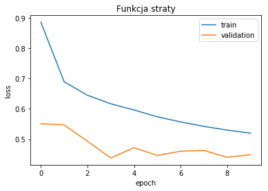

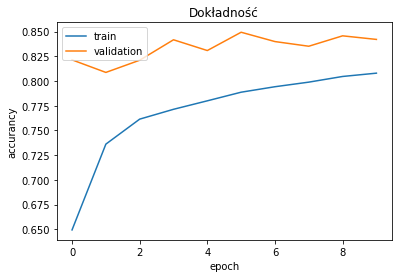

```python
history = model_1input.fit(X_train, y_train,
                    batch_size=256,
                    epochs=10,
                    verbose=1,
                    validation_data=(X_valid, y_valid),)

#WYKRESY OBRAZUJĄCE TRENING NASZEGO MODELU:

#funkcja straty
pyplot.plot(history.history['loss'])
pyplot.plot(history.history['val_loss'])
pyplot.title('Funkcja straty')
pyplot.ylabel('loss')
pyplot.xlabel('epoch')
pyplot.legend(['train', 'validation'], loc='upper right')
pyplot.show()

#dokładność
pyplot.plot(history.history['acc'])
pyplot.plot(history.history['val_acc'])
pyplot.title('Dokładność')
pyplot.ylabel('accurancy')
pyplot.xlabel('epoch')
pyplot.legend(['train', 'validation'], loc='upper left')
pyplot.show()
```

Ewaluacja na zbiorze testowym:

```python
score = model_1input.evaluate(X_test, y_test, batch_size=256, verbose=1)
print('Test loss:', score[0])
print('Test accuracy:', score[1])
```

```
Test loss: 0.4641830048904724
Test accuracy: 0.8409874746080621
```

```python
import tensorflow as tf
import keras.backend as K

def f1(y_true, y_pred):
    y_pred = K.round(y_pred)
    tp = K.sum(K.cast(y_true*y_pred, 'float'), axis=0)
    fp = K.sum(K.cast((1-y_true)*y_pred, 'float'), axis=0)
    fn = K.sum(K.cast(y_true*(1-y_pred), 'float'), axis=0)

    p = tp / (tp + fp + K.epsilon())
    r = tp / (tp + fn + K.epsilon())

    f1 = 2*p*r / (p+r+K.epsilon())
    f1 = tf.where(tf.is_nan(f1), tf.zeros_like(f1), f1)
    return K.mean(f1)
```

W przypadku niezbilansowanych danych (jak u nas), precyzyjniejsza będzie miara F1:

```python
y_pred = model_1input.predict(X_test)
print('Macro-F1-Score:', K.eval(f1(y_test, y_pred)))
```

```
Macro-F1-Score: 0.6391686
```

# Model z 3 wejściami

3 wypowiedzi z naszego dialogu jako input:

```python
input_turn1 = Input(shape=(None,), dtype='int32', name='input_turn1')
embedding_1 = Embedding(vocab_size_3 , 100, input_length=max_len_3,weights=[embedding_matrix_3], trainable=False, name='embedding_1')(input_turn1)
lstm_1 = LSTM(32, dropout=0.2, recurrent_dropout=0.1, name='lstm_1')(embedding_1)

input_turn2 = Input(shape=(None,), dtype='int32', name='input_turn2')
embedding_2 = Embedding(vocab_size_3 , 100, input_length=max_len_3, weights=[embedding_matrix_3], trainable=False, name='embedding_2')(input_turn2)
lstm_2 = LSTM(32, dropout=0.2, recurrent_dropout=0.1, name='lstm_2')(embedding_2)

input_turn3 = Input(shape=(None,), dtype='int32', name='input_turn3')
embedding_3 = Embedding(vocab_size_3 , 100, input_length=max_len_3, weights=[embedding_matrix_3], trainable=False, name='embedding_3')(input_turn3)
lstm_3 = LSTM(64, dropout=0.2, recurrent_dropout=0.1, name='lstm_3')(embedding_3)

concatenated = concatenate([lstm_1, lstm_2, lstm_3], axis=-1)
dense_hidden = Dense(256, activation='relu', name='dense_hidden')(concatenated)
emotion = Dense(4, activation = 'softmax', name='emotion')(dense_hidden)

model_3inputs = Model([input_turn1, input_turn2, input_turn3], emotion)

model_3inputs.compile(loss='categorical_crossentropy', optimizer='adam', metrics=['accuracy'])

print(model_3inputs.summary())
```

```
__________________________________________________________________________________________________
Layer (type)                    Output Shape         Param #     Connected to
==================================================================================================
input_turn1 (InputLayer)        (None, None)         0
__________________________________________________________________________________________________
input_turn2 (InputLayer)        (None, None)         0
__________________________________________________________________________________________________
input_turn3 (InputLayer)        (None, None)         0
__________________________________________________________________________________________________
embedding_1 (Embedding)         (None, 143, 100)     1683100     input_turn1[0][0]
__________________________________________________________________________________________________
embedding_2 (Embedding)         (None, 143, 100)     1683100     input_turn2[0][0]
__________________________________________________________________________________________________
embedding_3 (Embedding)         (None, 143, 100)     1683100     input_turn3[0][0]
__________________________________________________________________________________________________
lstm_1 (LSTM)                   (None, 32)           17024       embedding_1[0][0]
__________________________________________________________________________________________________
lstm_2 (LSTM)                   (None, 32)           17024       embedding_2[0][0]
__________________________________________________________________________________________________
lstm_3 (LSTM)                   (None, 64)           42240       embedding_3[0][0]
__________________________________________________________________________________________________
concatenate_2 (Concatenate)     (None, 128)          0           lstm_1[0][0]
                                                                 lstm_2[0][0]
                                                                 lstm_3[0][0]
__________________________________________________________________________________________________
dense_hidden (Dense)            (None, 256)          33024       concatenate_2[0][0]
__________________________________________________________________________________________________
emotion (Dense)                 (None, 4)            1028        dense_hidden[0][0]
==================================================================================================
Total params: 5,159,640
Trainable params: 110,340
Non-trainable params: 5,049,300
__________________________________________________________________________________________________
None
```

```python
SVG(model_to_dot(model_3inputs).create(prog='dot', format='svg'))
```

[figure not shown]

```
WARNING:tensorflow:From /usr/local/lib/python3.6/dist-packages/tensorflow/python/ops/math_ops.py:3066: to_int32 (from tensorflow.python.ops.math_ops) is deprecated and will be removed in a future version.
Instructions for updating:
Use tf.cast instead.
Train on 30160 samples, validate on 2755 samples
```

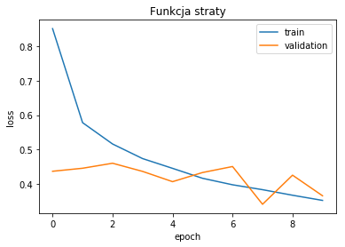

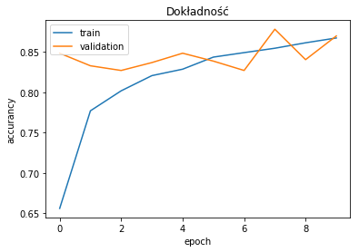

```python
history_3 = model_3inputs.fit({'input_turn1' : X_train_turn1, 'input_turn2' : X_train_turn2, 'input_turn3' : X_train_turn3},
                    y_train,
                    batch_size=256,
                    epochs=10,
                    verbose=1,
                    validation_data=({'input_turn1' : X_valid_turn1, 'input_turn2' : X_valid_turn2, 'input_turn3' : X_valid_turn3}, y_valid),)

#WYKRESY OBRAZUJĄCE TRENING NASZEGO MODELU:

#funkcja straty
pyplot.plot(history_3.history['loss'])
pyplot.plot(history_3.history['val_loss'])
pyplot.title('Funkcja straty')
pyplot.ylabel('loss')
pyplot.xlabel('epoch')
pyplot.legend(['train', 'validation'], loc='upper right')
pyplot.show()

#dokładność
pyplot.plot(history_3.history['acc'])
pyplot.plot(history_3.history['val_acc'])
pyplot.title('Dokładność')
pyplot.ylabel('accurancy')
pyplot.xlabel('epoch')
pyplot.legend(['train', 'validation'], loc='upper left')
pyplot.show()
```

```python
score = model_3inputs.evaluate({'input_turn1' : X_test_turn1, 'input_turn2' : X_test_turn2, 'input_turn3' : X_test_turn3},
                    y_test, batch_size=256, verbose=1)
print('Test loss:', score[0])
print('Test accuracy:', score[1])
```

```
Test loss: 0.3780507472438244
Test accuracy: 0.8640406604123908
```

```python
y_pred = model_3inputs.predict({'input_turn1' : X_test_turn1, 'input_turn2' : X_test_turn2, 'input_turn3' : X_test_turn3})
print('Macro-F1-Score:', K.eval(f1(y_test, y_pred)))
```

```
Macro-F1-Score: 0.6975658
```

# Conclusions

Wyniki dla wszystkich wykorzystanych klasyfikatorów:

```python
print(f'Naive Bayes\naccuracy: {0.88}, f1: {0.63}\n')
print(f'SVC\naccuracy: {0.84}, f1: {0.61}\n')
print(f'Random Forest\naccuracy: {0.81}, f1: {0.6}\n')
print(f'Model 1 Input\naccuracy: {0.84}, f1: {0.64}\n')
print(f'Model 3 Inputs\naccuracy: {0.86}, f1: {0.7}')
```

```
Naive Bayes
accuracy: 0.88, f1: 0.63

SVC
accuracy: 0.84, f1: 0.61

Random Forest
accuracy: 0.81, f1: 0.6

Model 1 Input
accuracy: 0.84, f1: 0.64

Model 3 Inputs
accuracy: 0.86, f1: 0.7
```

W przypadku naszych mało zbilansowanych danych, gdzie należy do klasy 'others' w wynikach sugerowaliśmy się miarą 'f1-score'. Tak jak się spodziewaliśmy najlepsze wyniki wyszły dla sieci neuronowej z trzema wejściami.

# Future Work

W kolejnym kroku, chcieliśmy sprawdzić jak radziłyby sobie 2 najnowsze (z 2018 roku) modele językowe: ELMo i BERT

[figure not shown]

ELMo pozwala na reprezentacje słów, która zachowuje kontekst użytego słowa. Można posłużyć się użytymi przez nas modelami, aby sprawdzić czy wykorzystanie ELMo do stworzenia embeddingów pomoże uzyskać wyższe wyniki.

BERT - model, który przebił wiele innych do tej pory stworzonych modeli. Od końca 2018 roku góruje w świecie Przetwarzania Języka Naturalnego. Warto byłoby mu poświęcić uwagę i sprawdzić jak poradziłby sobie w przypadku naszego problemu.